# Quantile additive models using qgam and mgcViz

Matteo Fasiolo

October 07 2019

The `qgam` R package offers methods for fitting additive quantile regression models based on splines, using the methods described in [Fasiolo et al., 2017](https://arxiv.org/abs/1707.03307). It is useful to use `qgam` together with `mgcViz`, which extends the basic visualizations provided by `mgcv`.

The main fitting functions are:

- `qgam()` fits an additive quantile regression model to a single quantile. Very similar to `mgcv::gam()`. It returns an object of class `qgam`, which inherits from `mgcv::gamObject`.
- `mqgam()` fits the same additive quantile regression model to several quantiles. It is more efficient that calling `qgam()` several times, especially in terms of memory usage.
- `qgamV()` and `mqgamV()` are two convenient wrappers that fit quantile GAMs and return `gamViz` objects, for which `mgcViz` provides lots of visualizations.

# 1 Electricity demand forecasting example (1)

We load the data and remove holidays:

```r
library(mgcViz)
data(UKload)
head(UKload)
```

```
##     NetDemand       wM   wM_s95       Posan      Dow      Trend
## 25      38353 6.046364 5.558800 0.001369941   samedi 1293879600
## 73      41192 2.803969 3.230582 0.004109824 dimanche 1293966000
## 121     43442 2.097259 1.858198 0.006849706    lundi 1294052400
## 169     50736 3.444187 2.310408 0.009589588    mardi 1294138800
## 217     50438 5.958674 4.724961 0.012329471 mercredi 1294225200
## 265     50064 4.124248 4.589470 0.015069353    jeudi 1294311600
##     NetDemand.48 Holy Year                Date
## 25         38353    1 2011 2011-01-01 12:00:00
## 73         38353    0 2011 2011-01-02 12:00:00
## 121        41192    0 2011 2011-01-03 12:00:00
## 169        43442    0 2011 2011-01-04 12:00:00
## 217        50736    0 2011 2011-01-05 12:00:00
## 265        50438    0 2011 2011-01-06 12:00:00
```

```r
# Discard Christmas holiday and other holidays
library(lubridate)
Data <- UKload
Data$month <- month(as.POSIXlt(Data$Date, format="%d/%m/%Y"))
Data$day <- day(as.POSIXlt(Data$Date, format="%d/%m/%Y"))
chri <- (Data$month == 12 & Data$day > 20) | (Data$month == 1 & Data$day < 5) | (Data$Holy==1)
Data <- UKload[ !chri, ]
```

We fit a median QGAM, we get a `gamViz` object in two different ways:

```r
# Option 1
fit50 <- qgam(NetDemand ~ Dow + NetDemand.48 + s(wM) + s(wM_s95) + s(Trend, k = 4) + s(Posan, k = 30),
              qu = 0.5,
              data = Data)
```

```
## Estimating learning rate. Each dot corresponds to a loss evaluation.
## qu = 0.5........done
```

```r
fit50 <- getViz(fit50)

# Option 2
fit50 <- qgamV(NetDemand ~ Dow + NetDemand.48 + s(wM) + s(wM_s95) + s(Trend, k = 4) + s(Posan, k = 30),
               qu = 0.5,
               data = Data)
```

```
## Estimating learning rate. Each dot corresponds to a loss evaluation.
## qu = 0.5........done
```

We can plot all smooth effects:

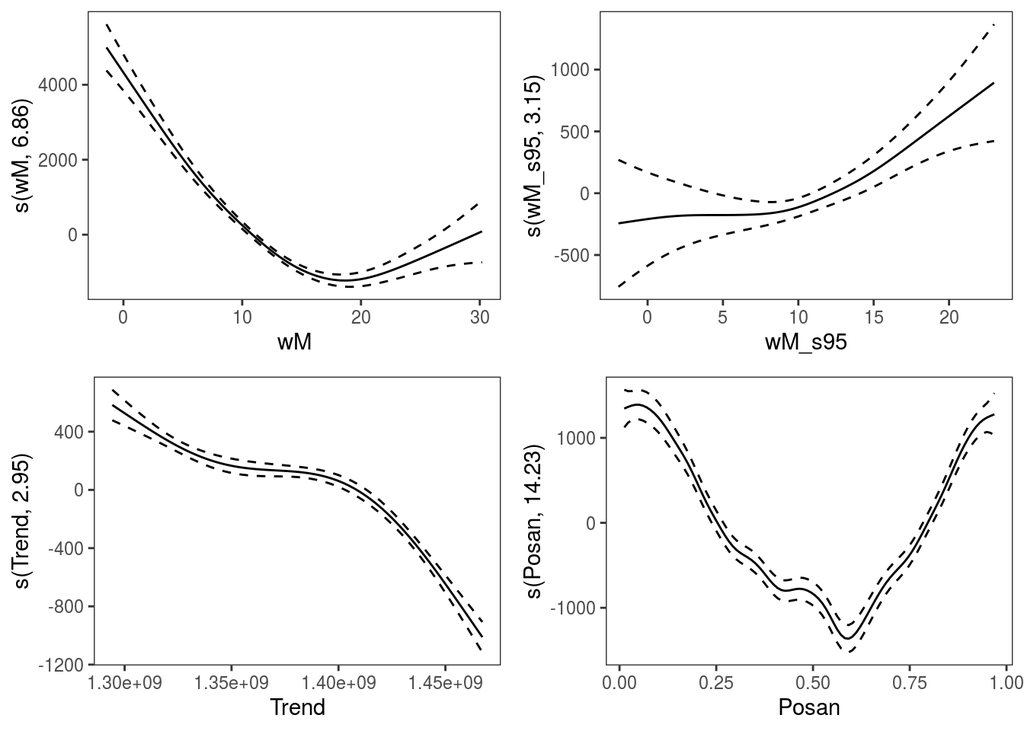

```r
print(plot(fit50), pages = 1)
```

We can check whether the proportion of negative residuals changes along `Posan`:

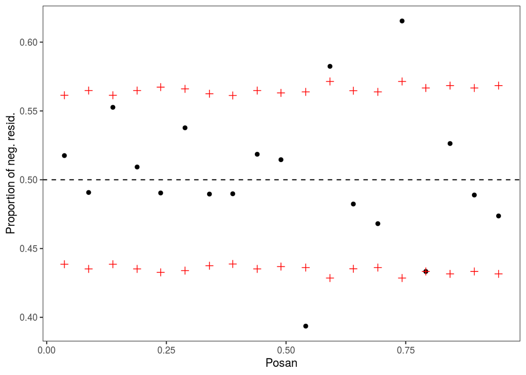

```r
check1D(fit50, "Posan") + l_gridQCheck1D()
```

We can check along several variables, because `check1D` is vectorised:

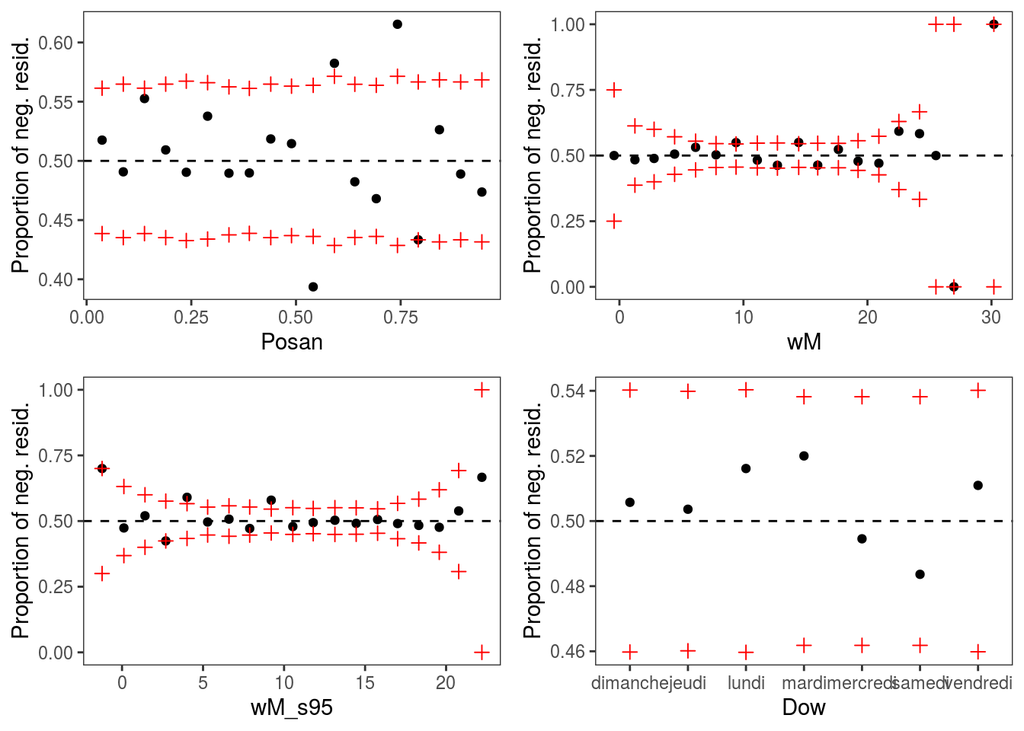

```r
print(check1D(fit50, list("Posan", "wM", "wM_s95", "Dow")) + l_gridQCheck1D(), pages = 1)
```

Simularly we can check along two variables:

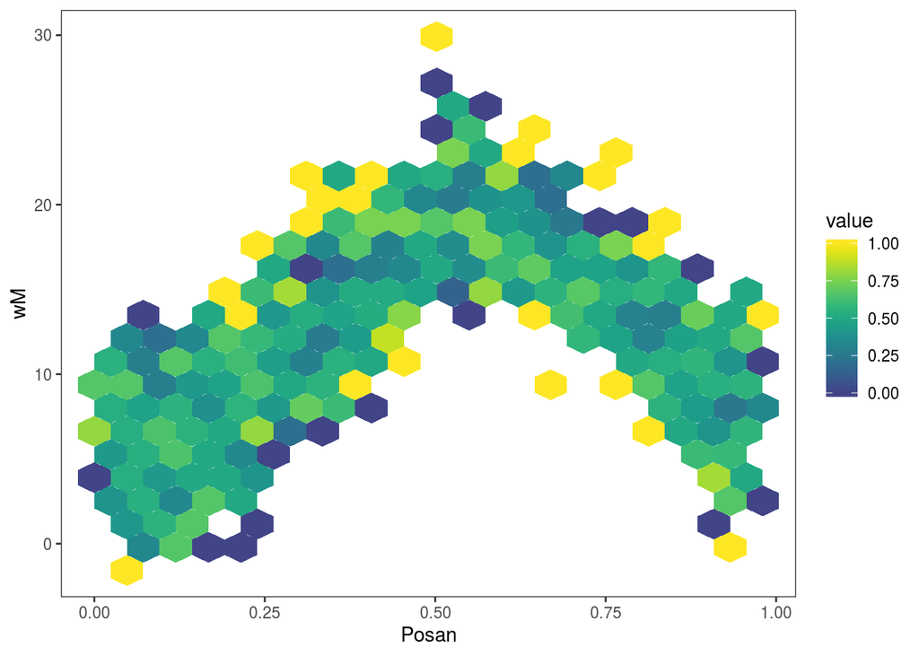

```r
check2D(fit50, "Posan", "wM") + l_gridQCheck2D(stand = FALSE)
```

Here we are not standardising, so each bin’s colour represents the proportion of negative residuals in that bin. By default standardisation is used to have an idea of the significance of the deviations from the chosen quantile (0.5 here):

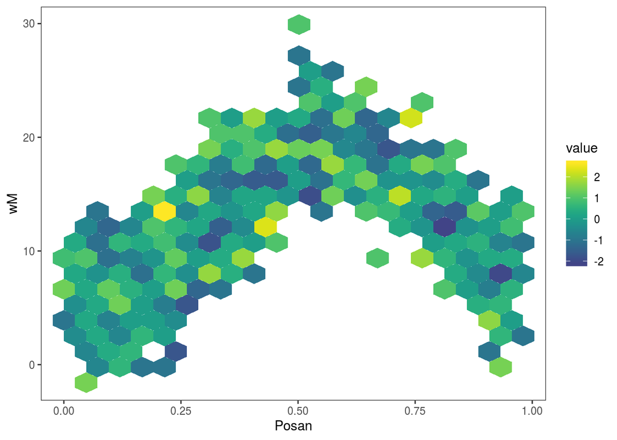

```r
check2D(fit50, "Posan", "wM") + l_gridQCheck2D()
```

Also `check2D` is vectorized, here is will check all pairs of variables:

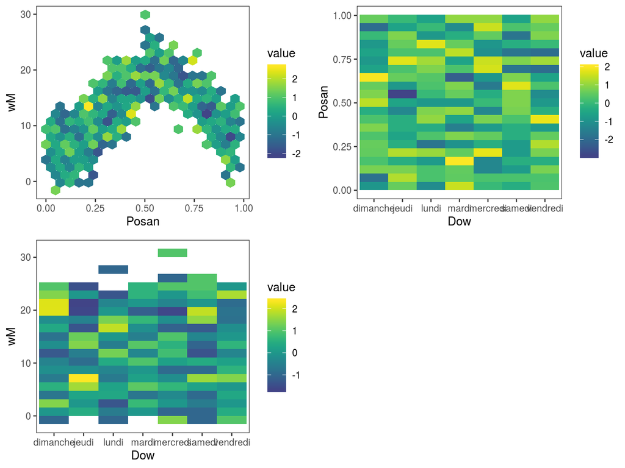

```r
print(check2D(fit50, list("Posan", "wM", "Dow")) + l_gridQCheck2D(), pages = 1)
```

Now we fit multiple quantiles:

```r
fitAll <- mqgamV(NetDemand ~ Dow + NetDemand.48 + s(wM) + s(wM_s95) + s(Trend, k = 4) + s(Posan, k = 30),
                 qu = c(0.1, 0.25, 0.5, 0.75, 0.9),
                 data = Data)
```

```
## Estimating learning rate. Each dot corresponds to a loss evaluation.
## qu = 0.5........done
## qu = 0.25..............done
## qu = 0.75...............done
## qu = 0.1....................done
## qu = 0.9...........done
```

Then we can plot of smooth effects together:

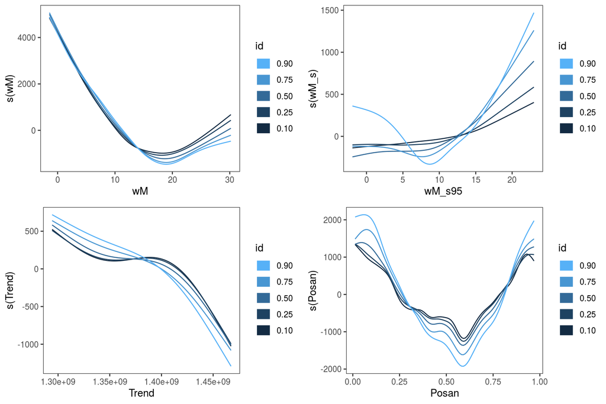

```r
print(plot(fitAll), pages = 1)
```

Or we can extract one of the smooth effects, and plot it for all quantiles:

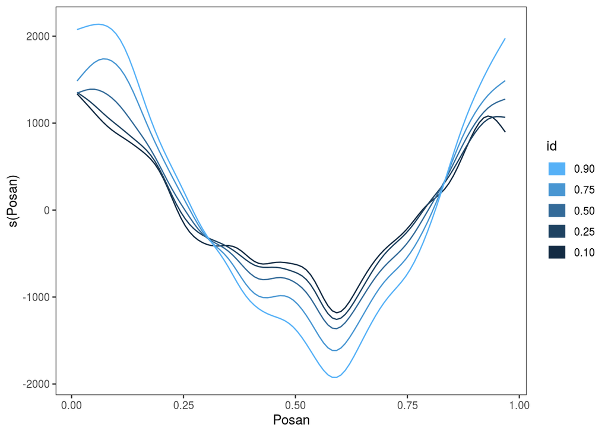

```r
plot(sm(fitAll, 4))
```

We can do the same for parametric terms:

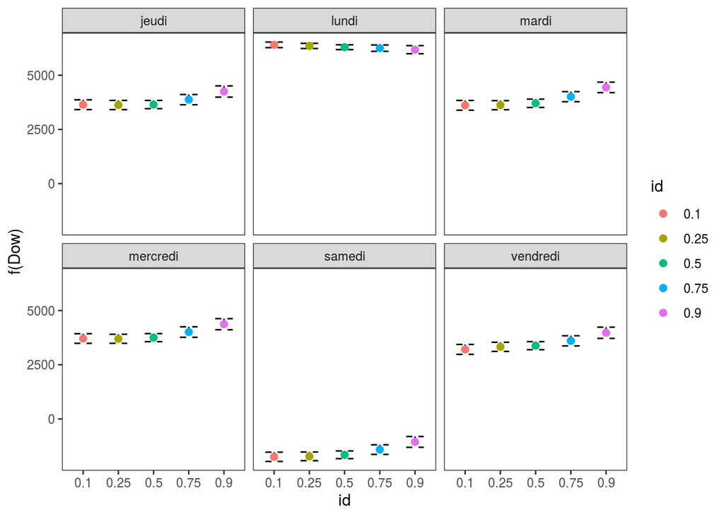

```r
plot(pterm(fitAll, 1))
```

Here `fitAll` is just a list of `gamViz` objects, we can handle them individually:

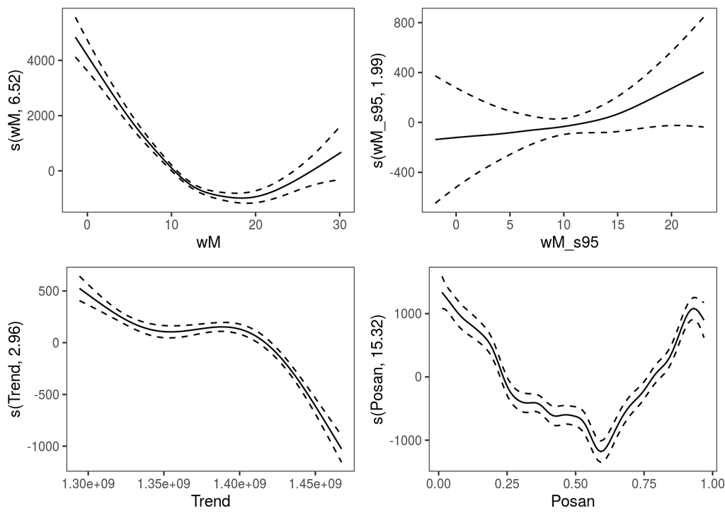

```r
fit10 <- fitAll[[1]]

print(plot(fit10), pages = 1)
```

# 2 Some details on the ELF loss

## 2.1 Setting the loss smoothness manually

Let’s simulate some data:

```r
set.seed(5235)
n <- 1000
x <- seq(-3, 3, length.out = n)
X <- cbind(1, x, x^2)
beta <- c(0, 1, 1)
f <- drop(X %*% beta)
dat <- f + rgamma(n, 4, 1)
dataf <- data.frame(cbind(dat, x))
names(dataf) <- c("y", "x")
```

Assume that we want to estimate quantiles 0.05, 0.5 and 0.95:

```r
fit <- mqgamV(y ~ s(x), data = dataf, qu = c(0.05, 0.5, 0.95))
```

```
## Estimating learning rate. Each dot corresponds to a loss evaluation.
## qu = 0.5........done
## qu = 0.95........done
## qu = 0.05.................done
```

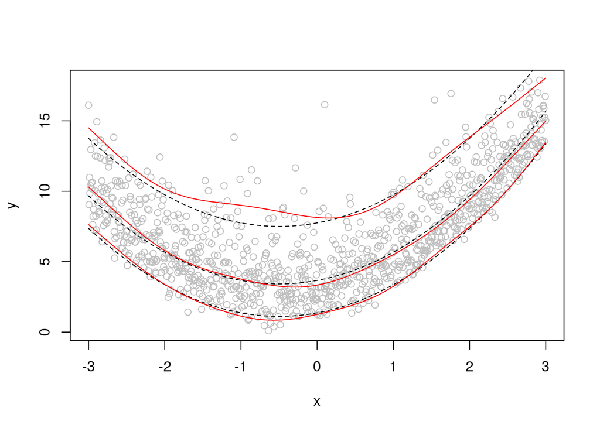

```r
plot(x, dat, col = "grey", ylab = "y")
lines(x, f + qgamma(0.95, 4, 1), lty = 2)
lines(x, f + qgamma(0.5, 4, 1), lty = 2)
lines(x, f + qgamma(0.05, 4, 1), lty = 2)
lines(x, predict(fit[[1]]), col = 2)
lines(x, predict(fit[[2]]), col = 2)
lines(x, predict(fit[[3]]), col = 2)
```

Let’s try to use several values of `err`:

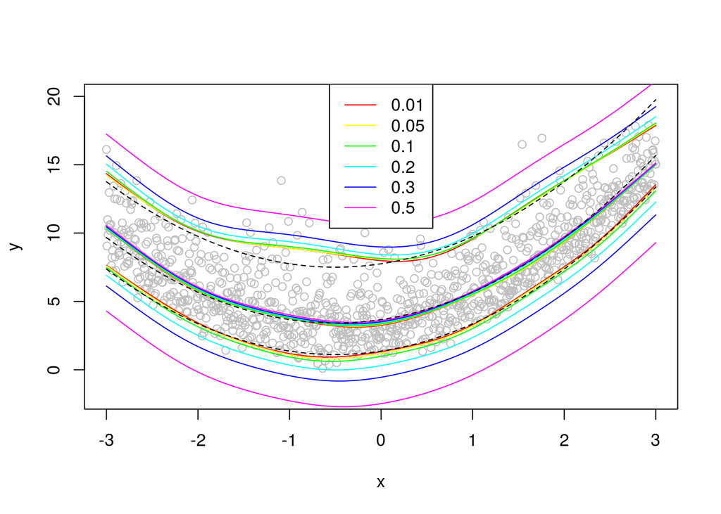

```r
lfit <- lapply(c(0.01, 0.05, 0.1, 0.2, 0.3, 0.5),
               function(.inp){
                 mqgamV(y ~ s(x), data = dataf, qu = c(0.05, 0.5, 0.95), err = .inp,
                        aQgam = list(control = list("progress" = F)))
               })

plot(x, dat, col = "grey", ylab = "y", ylim = c(-2, 20))
colss <- rainbow(length(lfit))
for(ii in 1:length(lfit)){
  lines(x, predict(lfit[[ii]][[1]]), col = colss[ii])
  lines(x, predict(lfit[[ii]][[2]]), col = colss[ii])
  lines(x, predict(lfit[[ii]][[3]]), col = colss[ii])
}
lines(x, f + qgamma(0.95, 4, 1), lty = 2)
lines(x, f + qgamma(0.5, 4, 1), lty = 2)
lines(x, f + qgamma(0.05, 4, 1), lty = 2)
legend("top", legend = c(0.01, 0.05, 0.1, 0.2, 0.3, 0.5), lty = 1, col = colss)
```

The bias increases with `err`, and it is upward (downward) for high (low) quantiles. The median fit is not much affected by `err`. The bias really starts appearing for `err > 0.1`. Decreasing `err` tends to slow down computation:

```r
system.time( fit1 <- qgamV(y ~ s(x), data = dataf, qu = 0.95,
                           aQgam = list(control = list("progress" = F))) )[[3]]
```

```
## [1] 0.305
```

```r
system.time( fit2 <- qgamV(y ~ s(x), data = dataf, qu = 0.95, err = 0.001,
                           aQgam = list(control = list("progress" = F))) )[[3]]
```

```
## [1] 29.712
```

Even worse, it can lead to numeric problems. Here we check that we have found the minimum of the calibration loss:

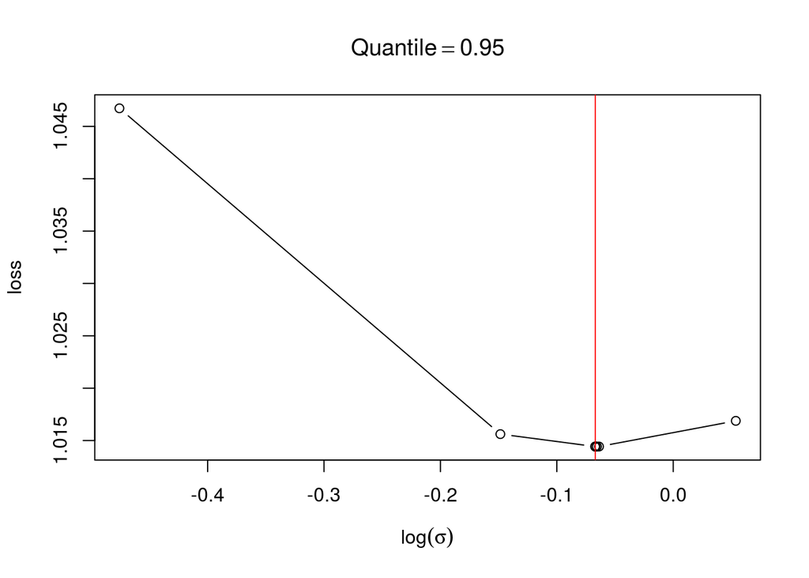

```r
check(fit1$calibr, sel = 2)
```

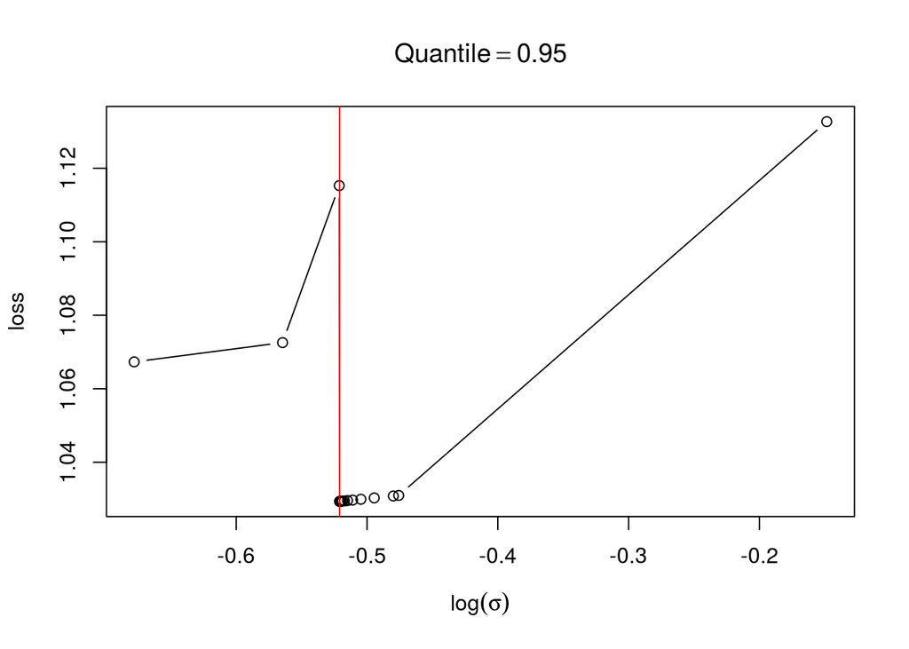

```r
check(fit2$calibr, sel = 2)
```

In the first case the loss looks smooth and with as single minimum, in the second case we have some instabilities. If the calibration loss looks like this, you generally have to increase `err`.

## 2.2 Modelling the loss smoothness and the learning rate

Let us consider the motorcycle data set:

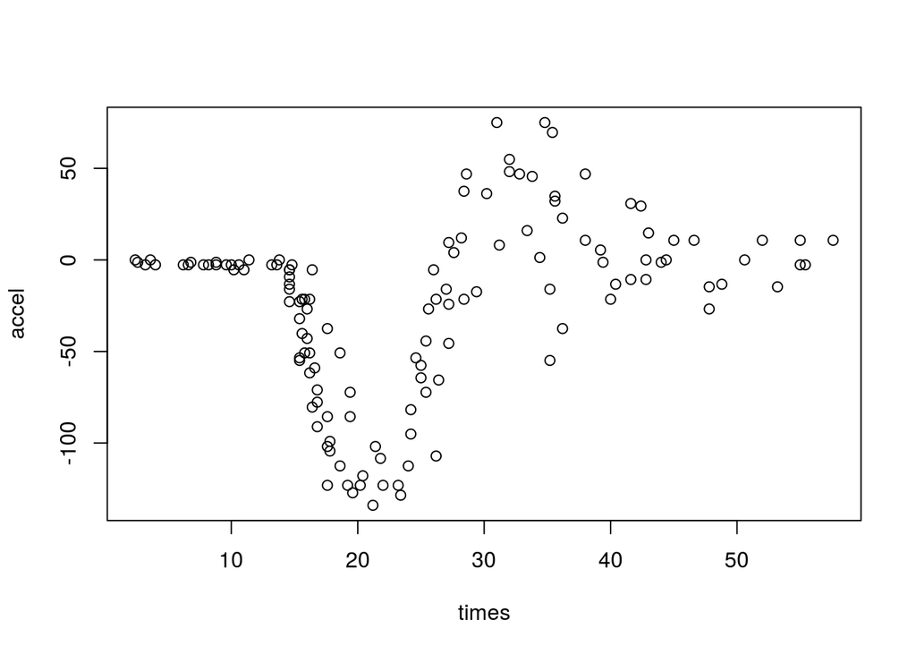

```r
library(MASS)
data(mcycle)
plot(mcycle)
```

Now we fit a quantile GAM for quantile 0.9

```r
fit09 <- qgam(accel ~ s(times, k=20, bs="ad"),
              data = mcycle,
              qu = 0.9)
```

```
## Estimating learning rate. Each dot corresponds to a loss evaluation.
## qu = 0.9....................done
```

We now plot the quantile with confidence intervals

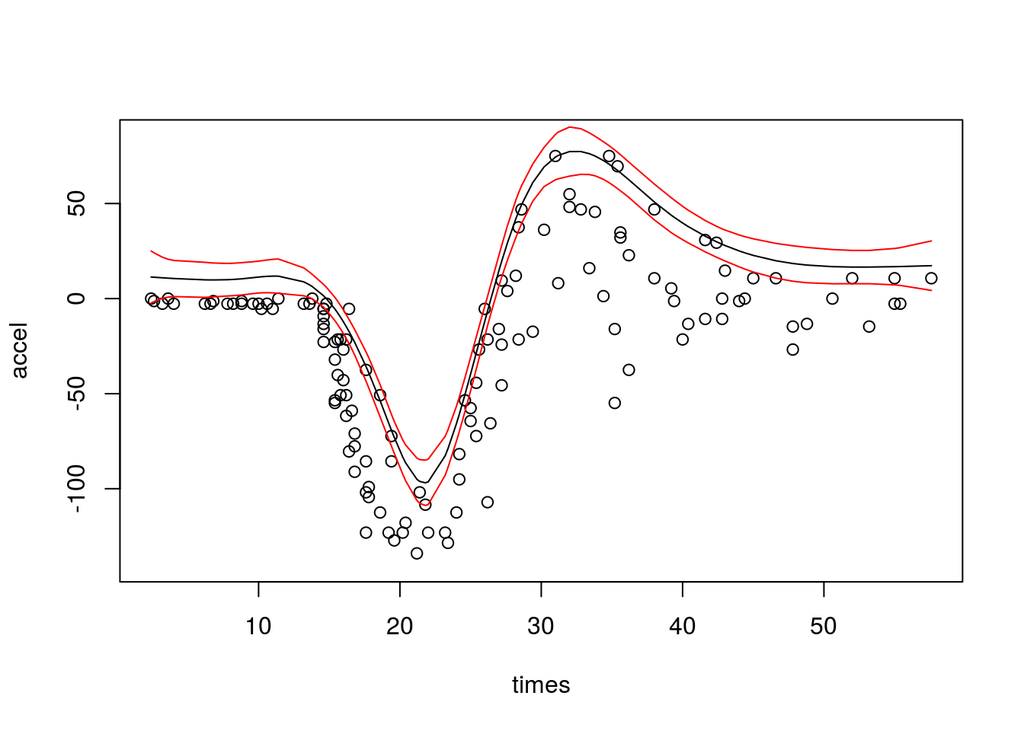

```r
pred <- predict(fit09, se = TRUE)

plot(mcycle, ylim = c(-140, 85))
lines(mcycle$times, pred$fit)
lines(mcycle$times, pred$fit + 2 * pred$se, col = 2)
lines(mcycle$times, pred$fit - 2 * pred$se, col = 2)
```

There are two problems with this fit:

- the confidence intervals have nearly constant width;
- the estimated quantile is far above the data for `times < 15`.

We address these issues by modelling the learning rate as well

```r
fit09_2 <- qgam(list(accel ~ s(times, k=20, bs="ad"),
                           ~ s(times)),
                 data = mcycle,
                 qu = 0.9)
```

```
## Estimating learning rate. Each dot corresponds to a loss evaluation.
## qu = 0.9..........done
```

Again predict and plot

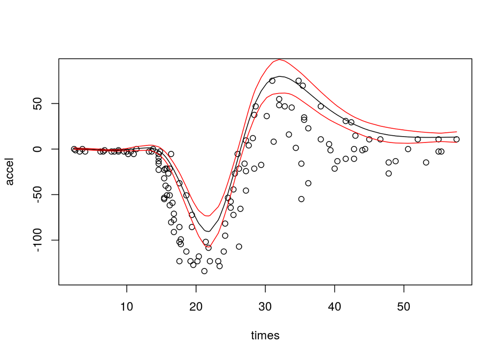

```r
pred <- predict(fit09_2, se = TRUE)

plot(mcycle, ylim = c(-140, 90))
lines(mcycle$times, pred$fit)
lines(mcycle$times, pred$fit + 2 * pred$se, col = 2)
lines(mcycle$times, pred$fit - 2 * pred$se, col = 2)
```

Looks much better!

# 3 Electricity demand forecasting (2): loss-based checks

We divide the data into training and testing set, and we fit an (over-simplified) median GAM:

```r
trainD <- Data[1:1000, ]
testD  <- Data[-(1:1000), ]

fit50 <- qgamV(NetDemand ~ Dow + s(wM, k = 4) + s(wM_s95, k = 4) + s(Trend, k = 4) + s(Posan, k = 4),
               qu = 0.5,
               data = trainD)
```

```
## Estimating learning rate. Each dot corresponds to a loss evaluation.
## qu = 0.5........done
```

Then we look at the distribution of the residuals:

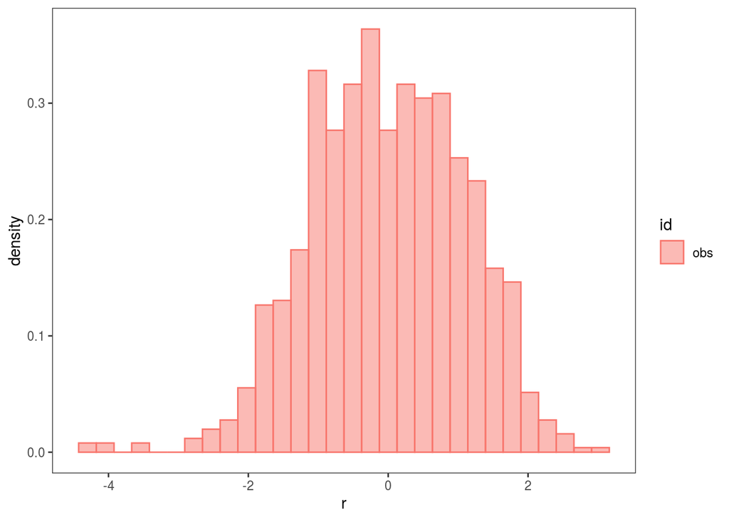

```r
check0D(fit50) + l_hist()
```

Looking at the residuals distribution is pretty useless for QGAM. It is better to look at the pinball loss. To do so we firstly create pinball loss function:

```r
pinball <- function(y, mu, qu){ # mu is fitted quantile, qu is quantile of interest
  tau <- 1 - qu
  d <- y - mu
  l <- d * 0
  l[d < 0] <- - tau*d[d<0]
  l[d > 0] <- - (tau-1)*d[d>0]
  return( l )
}
```

Then call again `check0D`, we specify that we are looking at raw observations `y`, and we transform them to pinball losses:

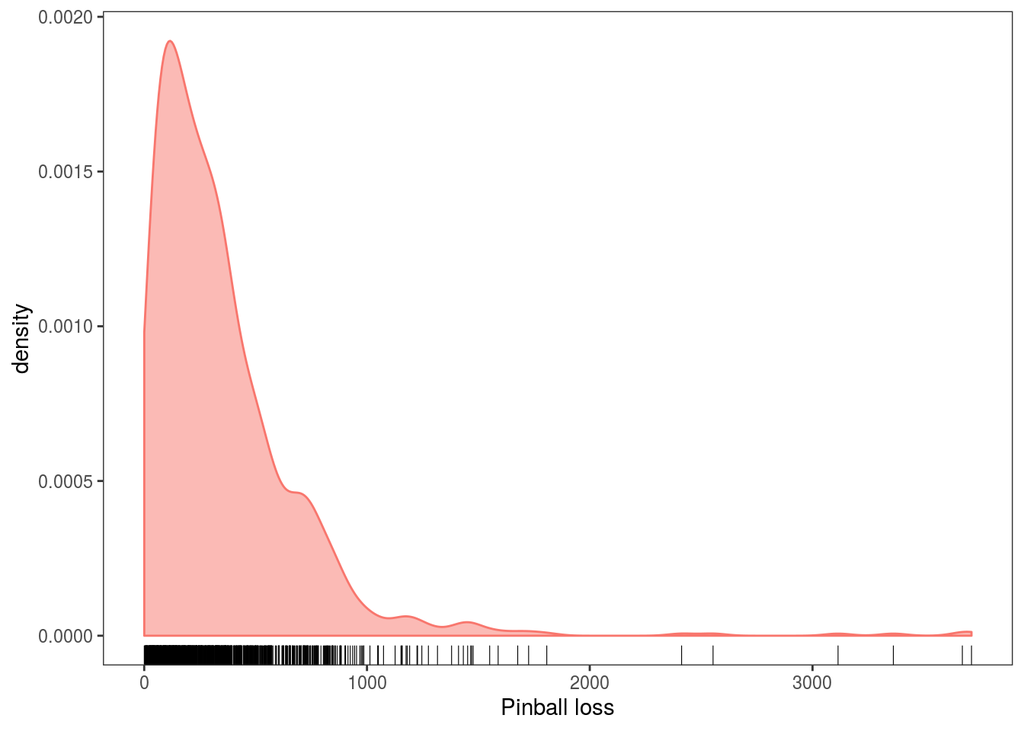

```r
check0D(fit50,
        type = "y",
        trans = function(y, ...) pinball(y, fit50$fitted.values, qu = 0.5)) +
        l_dens1D() + l_rug() + xlab("Pinball loss") + theme(legend.position="none")
```

So we have occasional very large losses on the training set. To look at the test set we do:

```r
fit50 <- getViz(fit50, newdata = testD)
```

This makes so that from now on all checks will be performed on `testD`, rather than `trainD`. For instance:

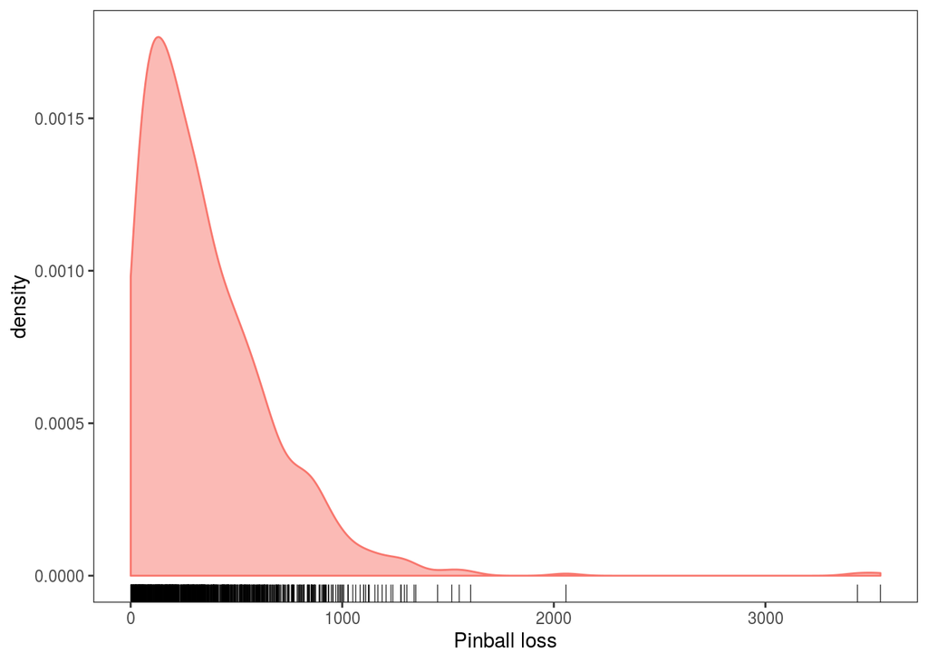

```r
check0D(fit50,
        type = "y",
        trans = function(y, ...) pinball(y, predict(fit50, newdata = testD), qu = 0.5)) +
        l_dens1D() + l_rug() + xlab("Pinball loss") + theme(legend.position="none")
```

Notice the call to `predict` on `testD` data set above.

We can also look at the losses along a variable such as `Posan`, on the test set:

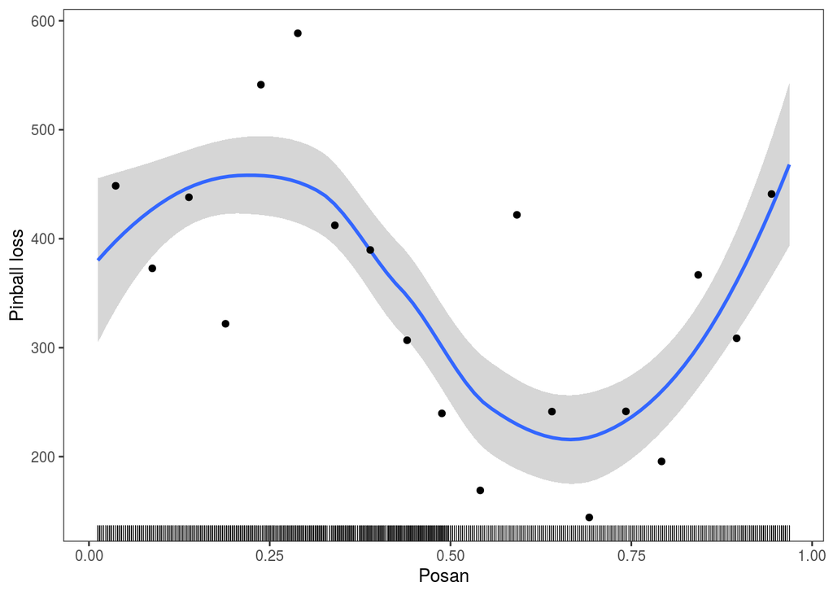

```r
check1D(fit50,
        x = "Posan",
        type = "y",
        trans = function(y, ...) pinball(y, predict(fit50, newdata = testD), qu = 0.5)) +
  geom_smooth() +
  l_gridCheck1D(gridFun = function(x, ...) ifelse(length(x) > 5, mean(x), NA), level = 0) +
  l_rug() + ylab("Pinball loss")
```

Give that `check1D` is vectorised, we can look along several variables by doing:

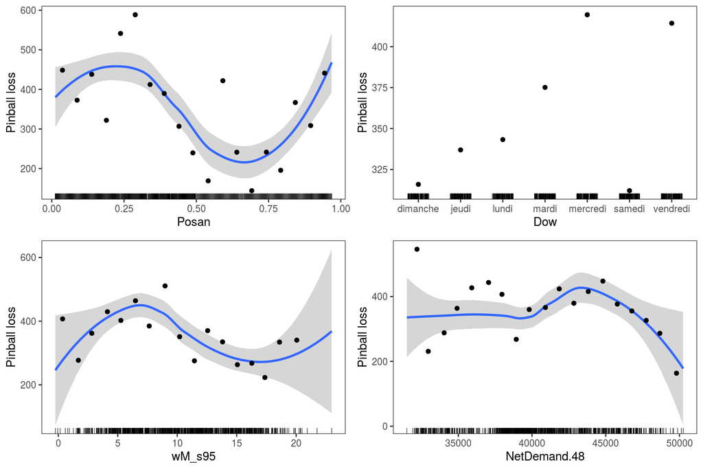

```r
pl <- check1D(fit50,
              x = list("Posan", "Dow", "wM_s95", "NetDemand.48"),
              type = "y",
              trans = function(y, ...) pinball(y, predict(fit50, newdata = testD), qu = 0.5)) +
  geom_smooth() +
  l_gridCheck1D(gridFun = function(x, ...) ifelse(length(x) > 5, mean(x), NA), level = 0) +
  l_rug() + ylab("Pinball loss")

print(pl, pages = 1)
```

To get confidence intervals for the pinball loss plot along `Dow`, we do:

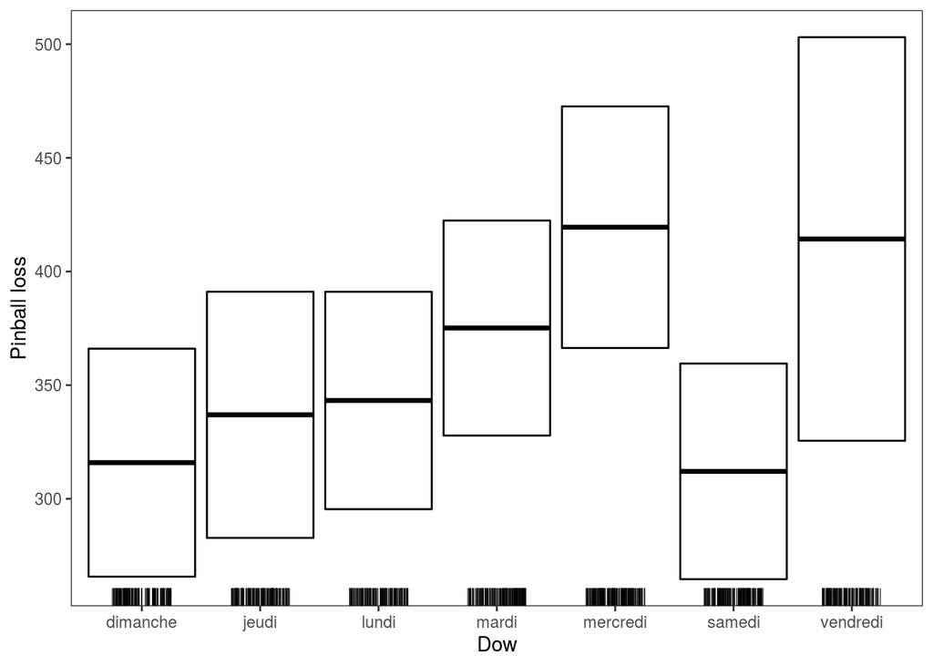

```r
check1D(fit50,
        x = "Dow",
        type = "y",
        trans = function(y, ...) pinball(y, predict(fit50, newdata = testD), qu = 0.5)) +
  stat_summary(fun.data = "mean_cl_normal", geom = "crossbar") +
  l_rug() + ylab("Pinball loss")
```

We can do something similar across two dimensions:

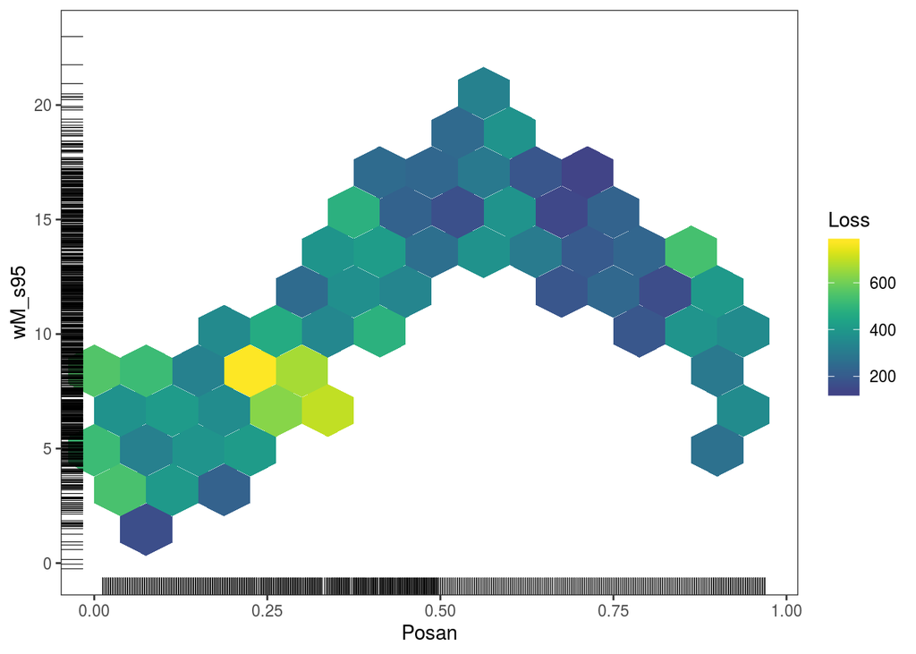

```r
check2D(fit50, "Posan", "wM_s95",
        type = "y",
        trans = function(y, ...) pinball(y, predict(fit50, newdata = testD), qu = 0.5)) +
  l_gridCheck2D(gridFun = function(x, ...) ifelse(length(x) > 5, mean(x), NA), stand = F, bw = c(0.075, 2)) +
  l_rug() + labs(fill="Loss")
```

Also here we can exploit vectorization:

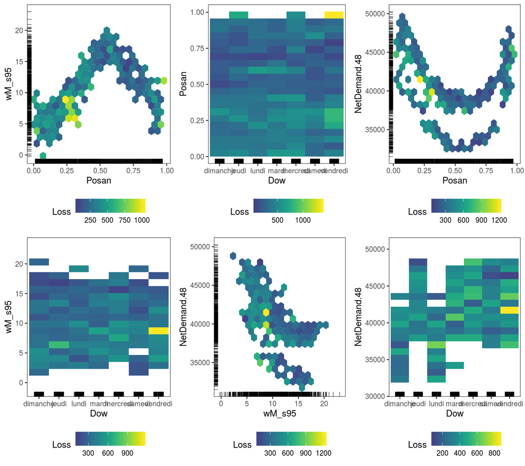

```r
pl <- check2D(fit50, list("Posan", "wM_s95", "Dow", "NetDemand.48"),
              type = "y",
              trans = function(y, ...) pinball(y, predict(fit50, newdata = testD), qu = 0.5)) +
  l_gridCheck2D(gridFun = function(x, ...) ifelse(length(x) > 2, mean(x), NA), stand = F) +
  l_rug() + theme(legend.position="bottom") + labs(fill="Loss")

print(pl, pages = 1)
```

If you instead want to perform the checks on the training set, you just need to do:

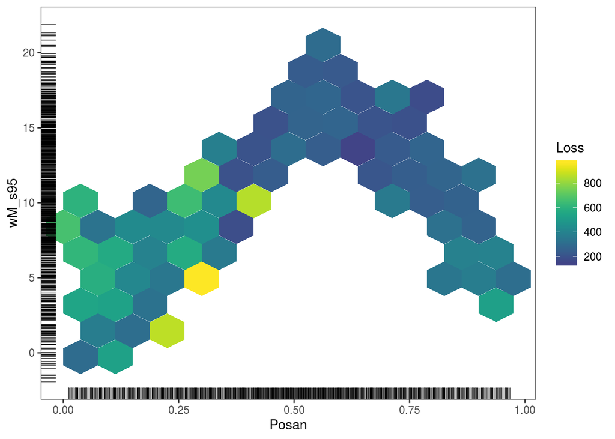

```r
fit50 <- getViz(fit50) # same as  fit50 <- getViz(fit50, newdata = trainD)

check2D(fit50, "Posan", "wM_s95",
        type = "y",
        trans = function(y, ...) pinball(y, predict(fit50, newdata = trainD), qu = 0.5)) +
  l_gridCheck2D(gridFun = function(x, ...) ifelse(length(x) > 5, mean(x), NA), stand = F, bw = c(0.075, 2)) +
  l_rug() + labs(fill="Loss")
```

# 4 References

- Fasiolo, M., Goude, Y., Nedellec, R. and Wood, S. N. (2017). Fast calibrated additive quantile regression. Available at https://arxiv.org/abs/1707.03307